# APTA Ridership Time Series Analysis

PSTAT 174

Isabella Escamilla

3/23/23

# Introduction

The goal of this analysis is to create a seasonal ARIMA model of the American Public Transportation Association (APTA) Ridership data set.

# Importing the Data

First, I will import the data and make any necessary modifications before turning them into time series.

```r
apta <- read.csv('data/apta_ridership_1990_2023.csv')
octa <- read.csv('data/octa_ridership_2002_2023.csv')

apta <- clean_names(apta)
octa <- clean_names(octa) %>% subset(select = -c(ntd_id, legacy_ntd_id, status,reporter_type,uza,uza_name,mode,tos))

apta_total <- apta$total_ridership_000s
octa %>% head()
```

|  | agency | x1_1_2002 | x2_1_2002 | x3_1_2002 | x4_1_2002 | x5_1_2002 | x6_1_2002 | x7_1_2002 | x8_1_2002 | x9_1_2002 | x10_1_2002 | x11_1_2002 | x12_1_2002 | x1_1_2003 | x2_1_2003 | x3_1_2003 | x4_1_2003 | x5_1_2003 | x6_1_2003 | x7_1_2003 | x8_1_2003 | x9_1_2003 | x10_1_2003 | x11_1_2003 | x12_1_2003 | x1_1_2004 | x2_1_2004 | x3_1_2004 | x4_1_2004 | … |
| --- | --- | --- | --- | --- | --- | --- | --- | --- | --- | --- | --- | --- | --- | --- | --- | --- | --- | --- | --- | --- | --- | --- | --- | --- | --- | --- | --- | --- | --- | --- |
| 1 | Orange County Transportation Authority | 4,958,849 | 4,788,129 | 5,232,774 | 5,357,847 | 5,577,551 | 5,251,925 | 5,533,213 | 5,552,990 | 5,378,477 | 5,786,210 | 5,100,052 | 5,075,270 | 5,288,888 | 4,781,810 | 5,541,939 | 5,510,851 | 5,493,831 | 5,240,785 | 5,452,900 | 5,465,806 | 5,626,885 | 5,773,798 | 5,032,321 | 5,201,126 | 5,269,279 | 5,180,964 | 5,994,608 | 5,723,400 | … |

In order to make the OCTA into a time series, we’ll need to melt the year columns and then grab the values.

```r
octa2 <- octa %>% melt(id=c('agency'))
octa2 %>% head()
```

|  | agency | variable | value |
| --- | --- | --- | --- |
| 1 | Orange County Transportation Authority | x1_1_2002 | 4,958,849 |
| 2 | Orange County Transportation Authority | x2_1_2002 | 4,788,129 |
| 3 | Orange County Transportation Authority | x3_1_2002 | 5,232,774 |
| 4 | Orange County Transportation Authority | x4_1_2002 | 5,357,847 |
| 5 | Orange County Transportation Authority | x5_1_2002 | 5,577,551 |
| 6 | Orange County Transportation Authority | x6_1_2002 | 5,251,925 |

```r
octa_vals <- octa2$value
```

The last thing we need to do is convert the numbers into numeric values, since they are currently characters.

```r
apta_total_num <- as.numeric(gsub(',', '', apta_total))
octa_vals_num <- as.numeric(gsub(',','', octa_vals))
```

Now we can make them into time series. The APTA data is quarterly and begins in Q1 of 1990 and ends in Q4 of 2022, so we’ll need to specify that. The OCTA data is monthly, beginning in January 2002 and ending on January 2023.

```r
apta_ts <- ts(apta_total_num, start = c(1990, 1),
                          end = c(2022, 4),
                          frequency = 4)

octa_ts <- ts(octa_vals_num, start = c(2002, 1),
                         end = c(2023, 1),
                         frequency = 12)
```

Now that we have our time series object, we can begin our analysis.

# SARIMA Modeling

For the first part of our analysis, we will be fitting a **SARIMA** (Seasonal Auto-Regressive Integrated Moving Average) model to both of our time series. In order to do so, we will first make the necessary transformations to the original time series before looking at ACF and PACF plots. We will then come up with the appropriate model and make any adjustments to the parameters that will improve model performance.

## Plotting the Time Series

First we’ll take a look at the log-scaled plots.

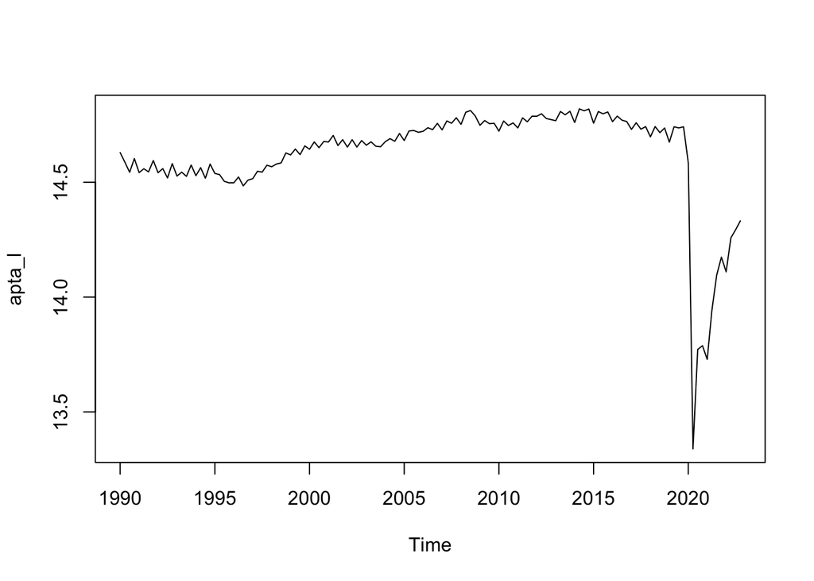

```r
apta_l <- log(apta_ts)
octa_l <- log(octa_ts)
p1 <- plot.ts(apta_l)
```

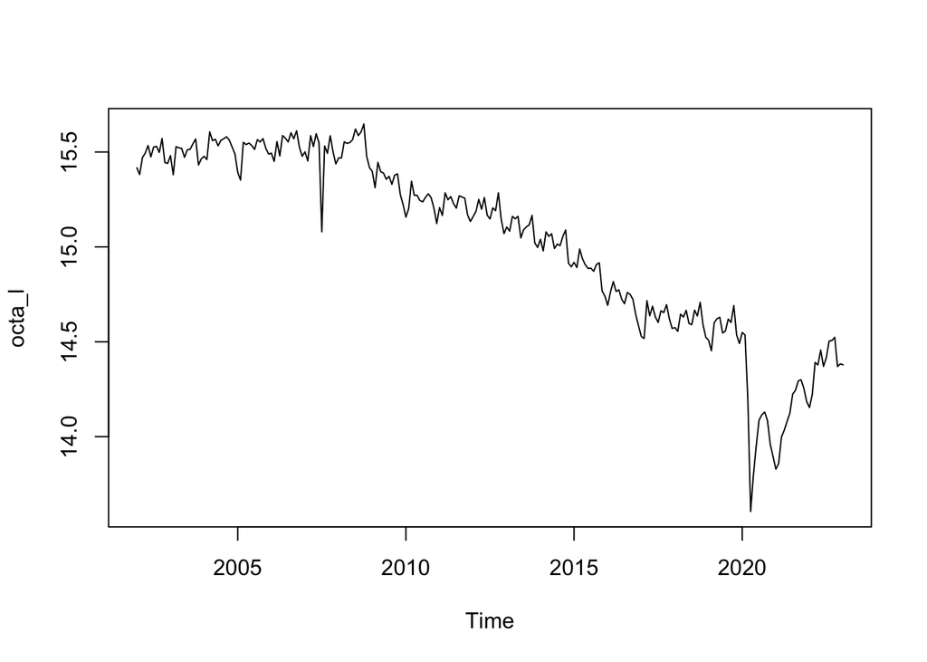

```r
p2 <- plot.ts(octa_l)
```

We can see that both plots feature a big dip at 2020 which is unsurprising, but will definitely affect our analysis. We can also see that there is somewhat of an upward trend for the APTA data before the dip and an upward trend after. The OCTA data appears to have a more clear downward trend. We will take the first difference of the data and investigate the plot.

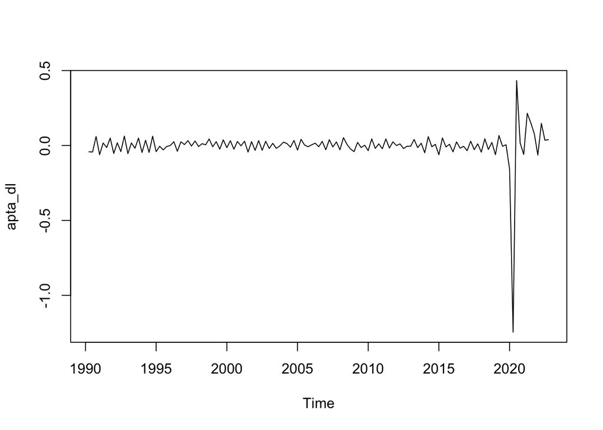

```r
apta_dl <- diff(apta_l)
octa_dl <- diff(octa_l)
plot.ts(apta_dl)
```

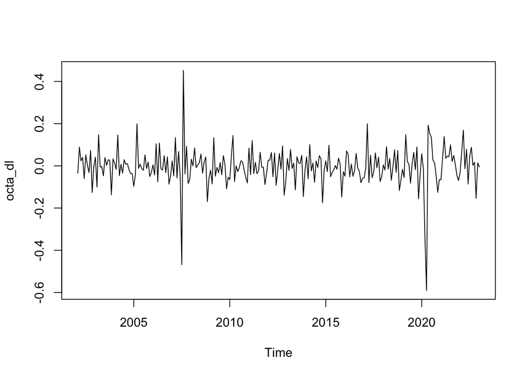

```r
plot.ts(octa_dl)
```

The first difference has de-trended the plots, so now we can look at the auto-correlation function (ACF) plots for each graph.

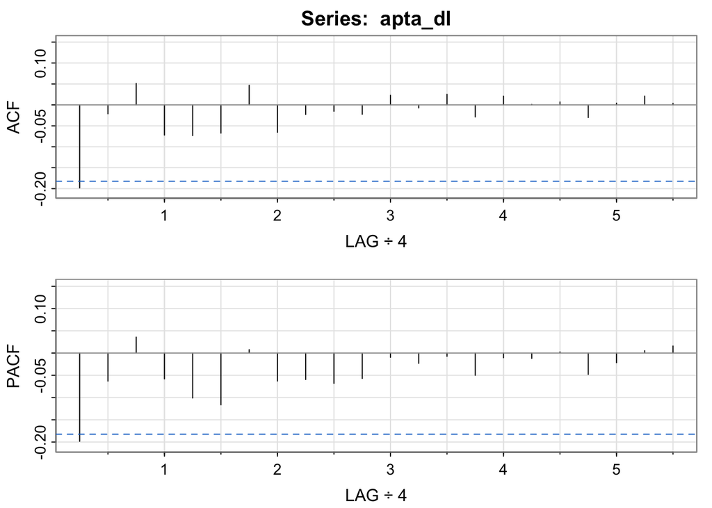

```
##      [,1]  [,2] [,3]  [,4]  [,5]  [,6] [,7]  [,8]  [,9] [,10] [,11] [,12] [,13]
## ACF  -0.2 -0.02 0.05 -0.07 -0.07 -0.07 0.05 -0.07 -0.02 -0.02 -0.02  0.02 -0.01
## PACF -0.2 -0.06 0.04 -0.06 -0.10 -0.12 0.01 -0.06 -0.06 -0.07 -0.06 -0.01 -0.02
##      [,14] [,15] [,16] [,17] [,18] [,19] [,20] [,21] [,22]
## ACF   0.03 -0.03  0.02  0.00  0.01 -0.03  0.00  0.02  0.00
## PACF -0.01 -0.05 -0.01 -0.01  0.00 -0.05 -0.02  0.01  0.02
```

```r
acf2(apta_dl)
```

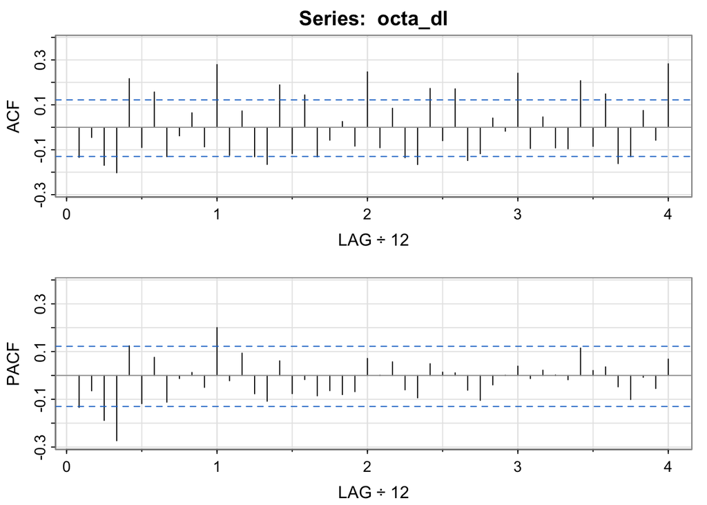

```
##       [,1]  [,2]  [,3]  [,4] [,5]  [,6] [,7]  [,8]  [,9] [,10] [,11] [,12]
## ACF  -0.13 -0.05 -0.17 -0.20 0.22 -0.09 0.16 -0.13 -0.04  0.06 -0.09  0.28
## PACF -0.13 -0.06 -0.19 -0.27 0.12 -0.12 0.08 -0.11 -0.01  0.01 -0.05  0.20
##      [,13] [,14] [,15] [,16] [,17] [,18] [,19] [,20] [,21] [,22] [,23] [,24]
## ACF  -0.13  0.07 -0.13 -0.17  0.19 -0.12  0.14 -0.13 -0.06  0.03 -0.08  0.25
## PACF -0.02  0.09 -0.08 -0.11  0.06 -0.08 -0.02 -0.09 -0.06 -0.08 -0.07  0.07
##      [,25] [,26] [,27] [,28] [,29] [,30] [,31] [,32] [,33] [,34] [,35] [,36]
## ACF  -0.09  0.08 -0.14 -0.17  0.17 -0.06  0.17 -0.15 -0.12  0.04 -0.02  0.24
## PACF  0.00  0.06 -0.06 -0.09  0.05  0.01  0.01 -0.06 -0.10 -0.04  0.00  0.04
##      [,37] [,38] [,39] [,40] [,41] [,42] [,43] [,44] [,45] [,46] [,47] [,48]
## ACF  -0.09  0.05 -0.09 -0.10  0.21 -0.08  0.15 -0.16 -0.13  0.07 -0.06  0.28
## PACF -0.01  0.02  0.00 -0.02  0.11  0.02  0.04 -0.05 -0.10 -0.01 -0.05  0.07
```

```r
acf2(octa_dl)
```

The ACF plot for OCTA has very clear spikes at lag differences of 1 which implies 12 month seasonality. The PACF corroborates this with a spike at lag 1. To address this, we will need to take a 12th difference for this data.

I will also take a 4th difference for the APTA to determine which model should be used for SARIMA.

## ACF and PACF Plots

To determine what SARIMA model we should use for these time series, we will look at the ACF and PACF plots after differencing out the seasonal component.

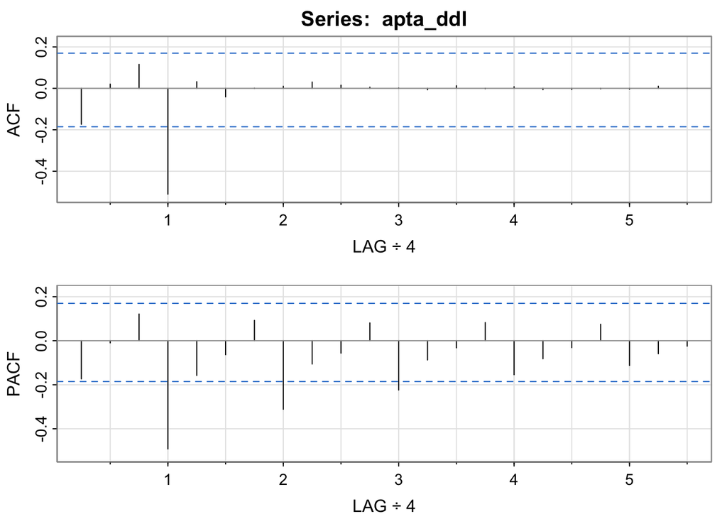

```
##       [,1]  [,2] [,3]  [,4]  [,5]  [,6] [,7]  [,8]  [,9] [,10] [,11] [,12]
## ACF  -0.17  0.02 0.12 -0.51  0.03 -0.04 0.00  0.01  0.03  0.02  0.01  0.00
## PACF -0.17 -0.01 0.12 -0.49 -0.16 -0.06 0.09 -0.31 -0.11 -0.06  0.08 -0.22
##      [,13] [,14] [,15] [,16] [,17] [,18] [,19] [,20] [,21] [,22]
## ACF  -0.01  0.01  0.00  0.01 -0.01 -0.01  0.00  0.00  0.01  0.00
## PACF -0.09 -0.03  0.08 -0.15 -0.08 -0.03  0.07 -0.11 -0.06 -0.02
```

```r
apta_ddl <- diff(apta_dl, 4)
octa_ddl <- diff(octa_dl, 12)
acf2(apta_ddl)
```

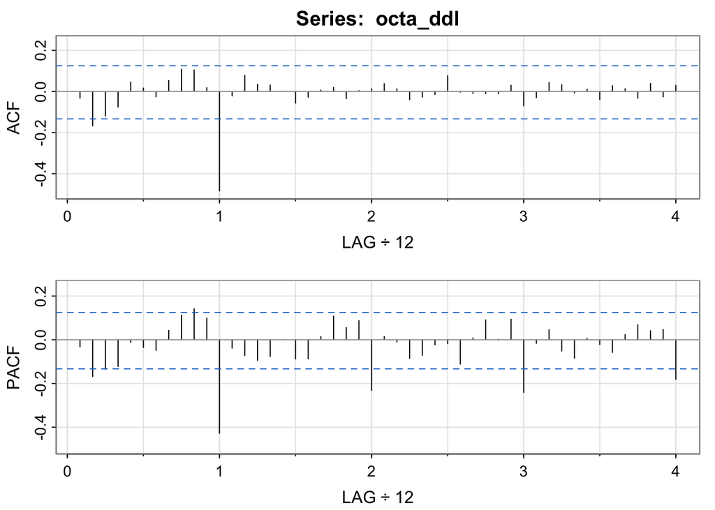

```
##       [,1]  [,2]  [,3]  [,4]  [,5]  [,6]  [,7] [,8] [,9] [,10] [,11] [,12]
## ACF  -0.03 -0.17 -0.12 -0.08  0.05  0.02 -0.03 0.05 0.11  0.10  0.02 -0.48
## PACF -0.03 -0.17 -0.13 -0.12 -0.01 -0.04 -0.05 0.04 0.11  0.14  0.10 -0.43
##      [,13] [,14] [,15] [,16] [,17] [,18] [,19] [,20] [,21] [,22] [,23] [,24]
## ACF  -0.02  0.08  0.03  0.03     0 -0.06 -0.03  0.01  0.02 -0.03  0.00  0.01
## PACF -0.04 -0.07 -0.09 -0.08     0 -0.09 -0.09  0.01  0.11  0.06  0.09 -0.23
##      [,25] [,26] [,27] [,28] [,29] [,30] [,31] [,32] [,33] [,34] [,35] [,36]
## ACF   0.04  0.01 -0.04 -0.03 -0.01  0.08  0.00 -0.01 -0.01 -0.01  0.03 -0.07
## PACF  0.01 -0.01 -0.09 -0.07 -0.02 -0.02 -0.11  0.01  0.09  0.00  0.09 -0.24
##      [,37] [,38] [,39] [,40] [,41] [,42] [,43] [,44] [,45] [,46] [,47] [,48]
## ACF  -0.03  0.04  0.03 -0.01  0.01 -0.04  0.03  0.01 -0.03  0.04 -0.03  0.03
## PACF -0.02  0.05 -0.05 -0.08  0.01 -0.02 -0.06  0.02  0.07  0.04  0.05 -0.18
```

```r
acf2(octa_ddl)
```

**APTA ACF/PACF Interpretation:** For the seasonal component, we want to look at the behavior of the graphs *at the lags*. Here, we can see that the ACF has a large negative spike at 1, while the PACF features geometric decay. This is indicative of a *seasonal* first-order moving average model.

For the non-seasonal component, we want to look at the behavior of the graphs *within the lags*. The ACF has a peak and then stays near zero while the PACF decays, so this could be a moving average model.

**OCTA ACF/PACF Interpretation:** The ACF and the PACF for the OCTA data exhibit similar behavior to the APTA data. At the lags, there is a spike at 1 for the ACF and geometric decay for the PACF. This means that a seasonal first-order moving average model would likely work here, too.

Between the lags, both the ACF and PACF appear to tail off, suggesting an ARMA(1,1) model.

## Fitting the SARIMA Model

Now that we have an idea of what models should be used for these series, we can begin fitting them.

First, we’ll try fitting the APTA time series to our SARIMA model.

```r
apta_sarima <- sarima(apta_l, 0,1,1, 0,1,1, 4, details=FALSE)
apta_sarima$ttable
```

```
##      Estimate     SE t.value p.value
## ma1   -0.2015 0.0881 -2.2879  0.0238
## sma1  -0.9786 0.1450 -6.7500  0.0000
```

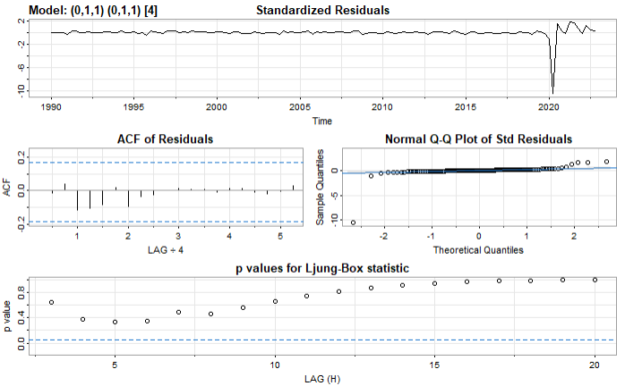

The coefficients are significant for both ma1 and sma1, and the diagnostic plots show that the ACF of the residuals are within the confidence interval, so we can go ahead with this model in our predictions.

Now, we will fit OCTA.

```r
octa_sarima <- sarima(octa_l, 1,1,1, 0,1,1, 12, details=FALSE)
octa_sarima$ttable
```

```
##      Estimate     SE t.value p.value
## ar1    0.6060 0.1437  4.2161       0
## ma1   -0.7586 0.1158 -6.5532       0
## sma1  -0.9998 0.1967 -5.0818       0
```

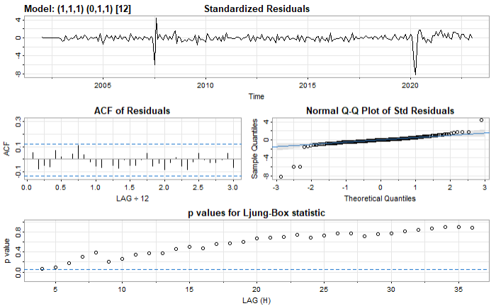

The ar1, ma1, and sma1 parameters are all significant! The diagnostic plot shows that the residuals are within the confidence interval, so we can use this model to make predictions for the OCTA time series.

## Forecasting

Now that we have our models, we can make forecasts.

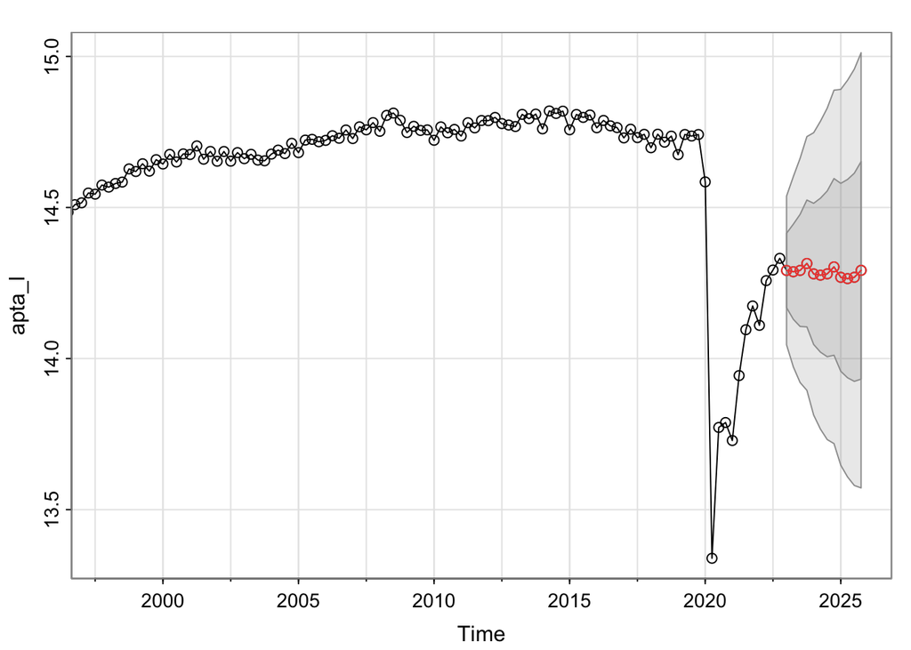

```
## $pred
##          Qtr1     Qtr2     Qtr3     Qtr4
## 2023 14.29166 14.28740 14.29176 14.31480
## 2024 14.28030 14.27603 14.28040 14.30343
## 2025 14.26893 14.26467 14.26904 14.29207
##
## $se
##           Qtr1      Qtr2      Qtr3      Qtr4
## 2023 0.1230334 0.1574234 0.1855453 0.2099333
## 2024 0.2336371 0.2547495 0.2742413 0.2924368
## 2025 0.3110196 0.3282056 0.3445355 0.3601257
```

```r
sarima.for(apta_l, 12, 0,1,1, 0,1,1, 4)
```

The SARIMA forecast for the APTA time series predicts that total ridership will remain relatively constant for the next 3 year with a bit of quarterly fluctuation.

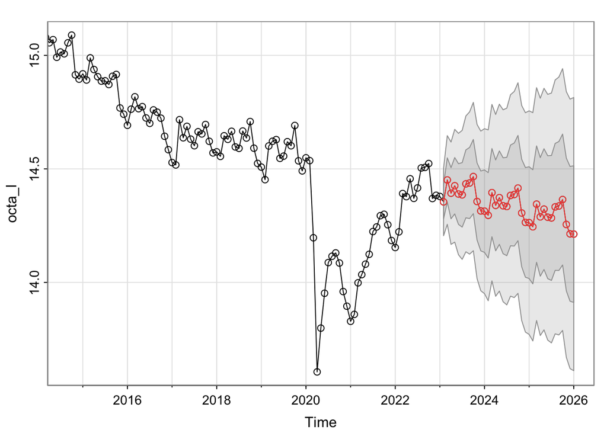

```
## $pred
##           Jan      Feb      Mar      Apr      May      Jun      Jul      Aug
## 2023          14.35463 14.45110 14.39290 14.42580 14.38930 14.38555 14.43404
## 2024 14.31379 14.29547 14.39535 14.33923 14.37338 14.33763 14.33435 14.38311
## 2025 14.26326 14.24496 14.34484 14.28872 14.32288 14.28713 14.28385 14.33261
## 2026 14.21276
##           Sep      Oct      Nov      Dec
## 2023 14.43783 14.46615 14.35633 14.31490
## 2024 14.38708 14.41549 14.30574 14.26435
## 2025 14.33658 14.36500 14.25524 14.21385
## 2026
##
## $se
##             Jan        Feb        Mar        Apr        May        Jun
## 2023            0.07447957 0.09762408 0.11265665 0.12409862 0.13361297
## 2024 0.18159372 0.18809852 0.19424860 0.20012997 0.20579668 0.21128427
## 2025 0.24615321 0.25136544 0.25636856 0.26121511 0.26593752 0.27055651
## 2026 0.30081522
##             Jul        Aug        Sep        Oct        Nov        Dec
## 2023 0.14196816 0.14956394 0.15662525 0.16328671 0.16963352 0.17572259
## 2024 0.21661720 0.22181330 0.22688627 0.23184730 0.23670617 0.24147191
## 2025 0.27508587 0.27953536 0.28391235 0.28822301 0.29247304 0.29666828
## 2026
```

```r
sarima.for(octa_l, 36, 1,1,1, 0,1,1, 12)
```

The SARIMA forecast for the OCTA time series predicts that bus ridership for the OCTA will decrease over the next 3 years while also following monthly fluctuations.

# ARIMAX Modeling

For the second part of our analysis, we will be taking the OCTA time series and adding a second variable, California GDP. To do this, we will fit an ARIMAX model (an ARIMA model but with an e**X**ogenous variable).

## Adjusting Data

First, I’ll have to import the GDP data and make sure that the periods and time span match each other.

```r
# Creating California GDP time series object
ca_gdp <- read.csv('data/SQGDP2_CA_2005_2022.csv')
ca_gdp2 <- clean_names(ca_gdp) %>% subset(select = -c(geo_fips,geo_name,table_name,line_code,industry_classification,description,unit))

ca_gdp3 <- ca_gdp2[1,] %>% melt(id = c('region'))

ca_gdp_ts <- ts(ca_gdp3$value,
                start = c(2005, 1),
                end = c(2022,3),
                frequency = 4)
```

We will need to alter the OCTA time series to match the GDP time series. This means making it quarterly instead of monthly, beginning in 2005 Q1, and ending in 2022 Q3.

```r
octa_quarterly_ts <- aggregate.ts(octa_ts, nfrequency = 4)
octa_q_ts <- window(octa_quarterly_ts,
                    start = c(2005, 1),
                    end = c(2022, 3))
```

Before beginning our model fitting, let’s look at how the time series compare.

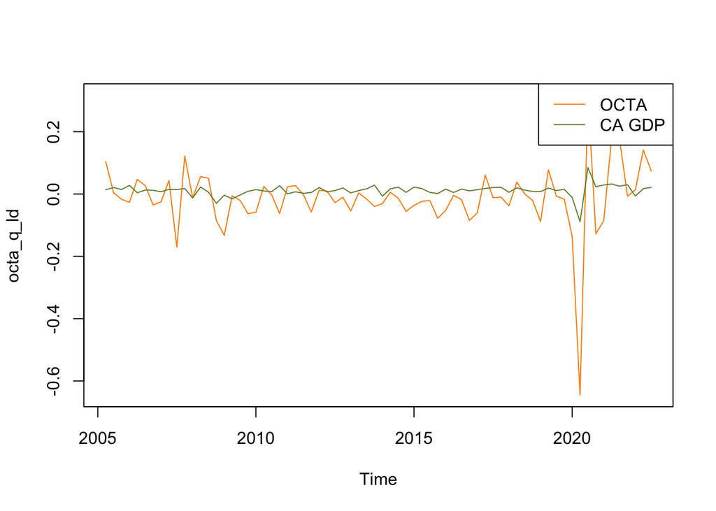

```r
ca_gdp_l <- log(ca_gdp_ts)
octa_q_l <- log(octa_q_ts)

ca_gdp_ld <- diff(ca_gdp_l)
octa_q_ld <- diff(octa_q_l)

plot(octa_q_ld, type='l', col='darkorange')
lines(ca_gdp_ld, col='darkolivegreen4')
legend('topright',
       legend=c('OCTA','CA GDP'),
       lty= 1,
       col=c('darkorange', 'darkolivegreen4'))
```

While OCTA ridership is generally more volatile than CA GDP, we can see that there is some relationship between the two graphs. The clearest example of this is in 2020 where both have a downward spike, but in other parts, the smaller spikes line up.

## Model Fitting

Now that we have our data matched up, we can now investigate whether CA GDP really does help explain some of the variation in OCTA. Since we found a good SARIMA model for the univariate OCTA time series, we will start by using those parameters and then adding CA GDP as an exogenous variable.

```r
model <- sarima(octa_q_l, 1,1,1, 0,1,1, 4, xreg=ca_gdp_l, details=FALSE)
model$ttable
```

```
##      Estimate     SE   t.value p.value
## ar1   -0.9998 0.0017 -579.7163       0
## ma1    0.9869 0.0519   19.0273       0
## sma1  -0.9567 0.1608   -5.9500       0
## xreg   4.2597 0.4478    9.5121       0
```

[figure not shown]

The table tells us that all of the parameters are significant. The `xreg` parameter in particular is quite significant which tells us that adding CA GDP as an exogenous variable helps in explaining variation in OCTA. This is an interesting result, since it points out a clear relationship between CA GDP and bus ridership in Orange County, California.

The diagnostic plots shed some more light on how this fit has performed. The standardized residuals have a smaller range compared to the original OCTA SARIMA model — the SARIMA residuals ranged from around -8 to 4 while the SARIMAX model ranges from around -3 to 2. This tells us that this model’s predictions fit the actual values more closely than the original. However, looking at the Ljung-Box statistic, we see that there are a number of values falling below the 0.05 range, which tells us that there could be variation that can be captured by changing the seasonality or adding more terms. We will try to capture this by increasing the period.

```r
model <- sarima(octa_q_l, 1,1,1, 0,1,1, 7, xreg=ca_gdp_l, details=FALSE)
model$ttable
```

```
##      Estimate     SE t.value p.value
## ar1   -0.5229 0.3647 -1.4337  0.1569
## ma1    0.6230 0.3210  1.9411  0.0570
## sma1  -0.7966 0.1481 -5.3771  0.0000
## xreg   4.4237 0.5379  8.2244  0.0000
```

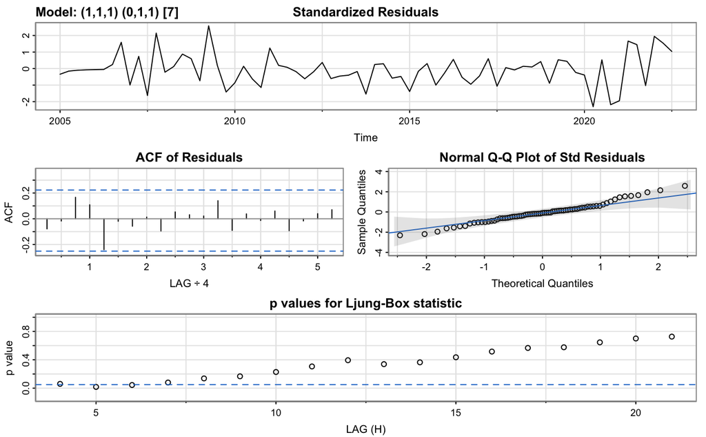

Setting the seasonal period at 7 has helped both the ACF and Ljung-Box plots, but now the AR1 and MA1 are not significant at significance level $\alpha = 0.05$, so we will remove them.

```r
model <- sarima(octa_q_l, 0,1,0, 0,1,1, 7, xreg=ca_gdp_l, details=FALSE)
model$ttable
```

```
##      Estimate     SE t.value p.value
## sma1  -0.7712 0.1394 -5.5328       0
## xreg   4.2912 0.5199  8.2538       0
```

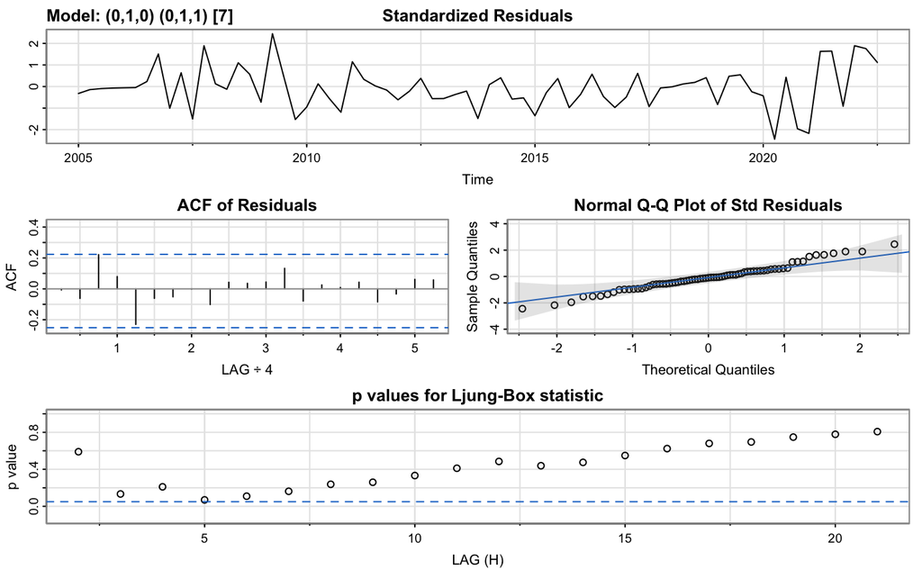

After removing these two parameters, the Ljung-Box statistic plot looks even better with no points dipping below the p-value threshold at 0.05. Additionally, the range of the models has shrunk to around -2 to 2.

# Lagged Regression

Fitting an ARIMAX model for the OCTA data with CA GDP as an exogenous variable showed that there is a strong relationship between the two. To investigate this relationship further, a lagged regression could be useful.

First, we will find what model would work with the detrended CA GDP.

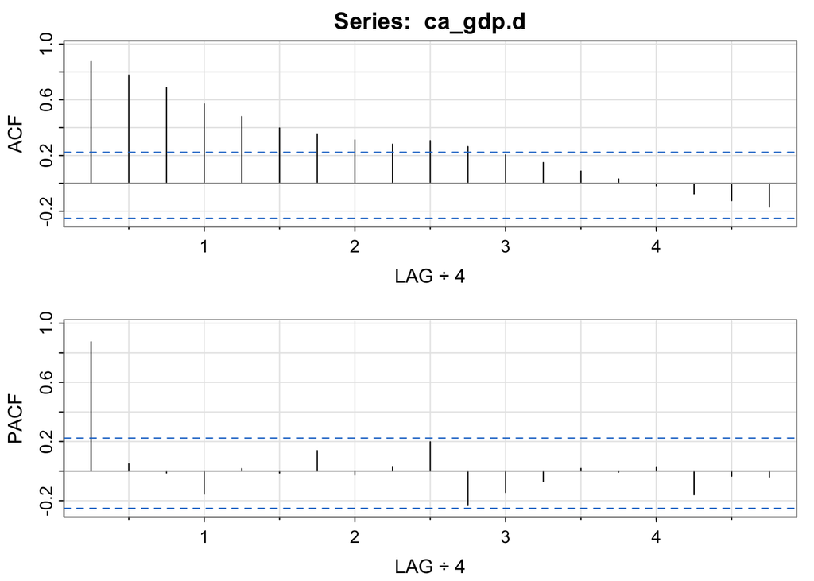

```
##      [,1] [,2]  [,3]  [,4] [,5]  [,6] [,7]  [,8] [,9] [,10] [,11] [,12] [,13]
## ACF  0.87 0.78  0.69  0.57 0.48  0.40 0.35  0.31 0.28  0.31  0.26  0.20  0.15
## PACF 0.87 0.05 -0.01 -0.16 0.02 -0.01 0.14 -0.03 0.03  0.20 -0.23 -0.14 -0.07
##      [,14] [,15] [,16] [,17] [,18] [,19]
## ACF   0.09  0.03 -0.02 -0.08 -0.12 -0.17
## PACF  0.02 -0.01  0.03 -0.16 -0.03 -0.04
```

```r
ca_gdp.d <- resid(lm(ca_gdp_ts ~ time(ca_gdp_ts), na.action=NULL)) # Detrended OCTA
acf2(ca_gdp.d)
```

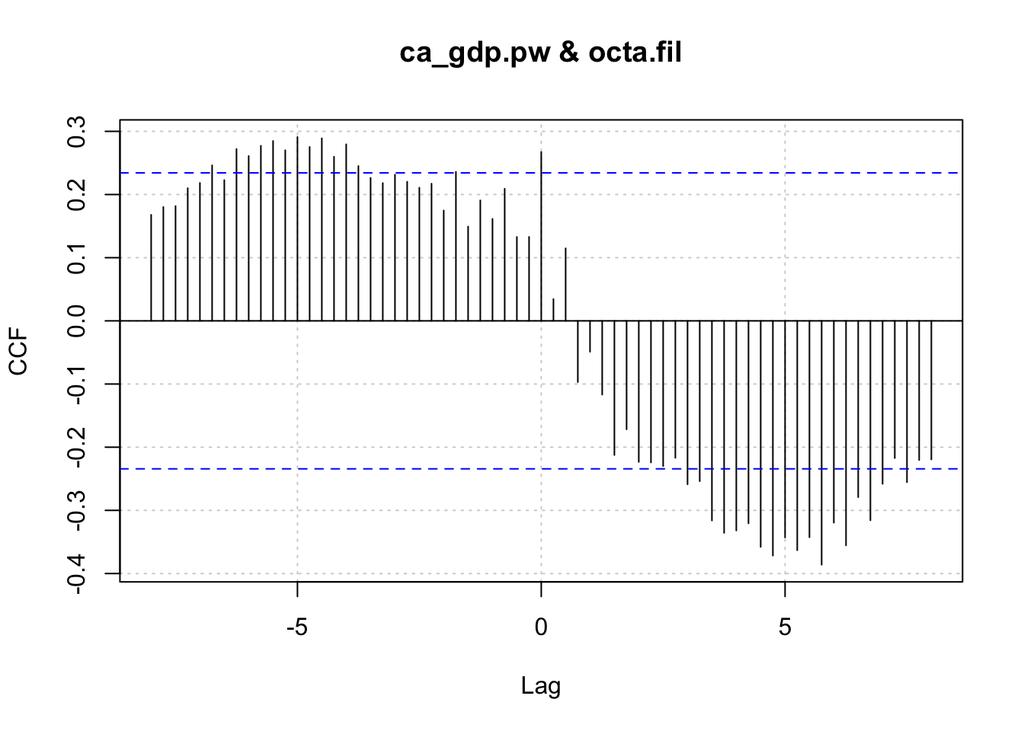

```r
fit <- arima(ca_gdp.d, order=c(0,0,1))
ma1 <- as.numeric(coef(fit)[1]) # Grabs the coefficient value of MA1, 0.8204
ca_gdp.pw <- resid(fit)
octa.fil <- stats::filter(octa_q_ts, filter=c(1, -ma1), sides=1)
ccf(ca_gdp.pw, octa.fil, ylab="CCF", lag.max = 32, na.action=na.omit, panel.first=grid())
```

The other thing that the graph tells us is the time shift between the CA GDP and OCTA. The graph peaks at around -5 and 5, so a time shift of $5*4=20$ would work best here.

Now that we have this information, we can can fit the transfer function model which allows for autocorrelated errors and do one-step-ahead predictions.

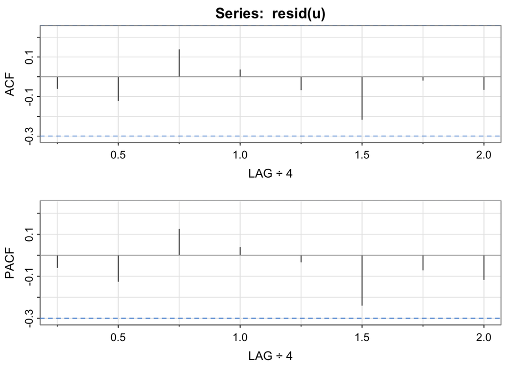

```
##       [,1]  [,2] [,3] [,4]  [,5]  [,6]  [,7]  [,8]
## ACF  -0.06 -0.12 0.14 0.04 -0.07 -0.22 -0.02 -0.06
## PACF -0.06 -0.12 0.12 0.04 -0.03 -0.24 -0.07 -0.12
```

```r
octa_q_ts2 <- ts.intersect(octa_q_ts, RL1 = stats::lag(octa_q_ts, -1), SL5 = stats::lag(ca_gdp.d, -20))
u <- lm(octa_q_ts2[,1]~octa_q_ts2[,2:3], na.action=NULL)
acf2(resid(u)) # suggests a white noise model
```

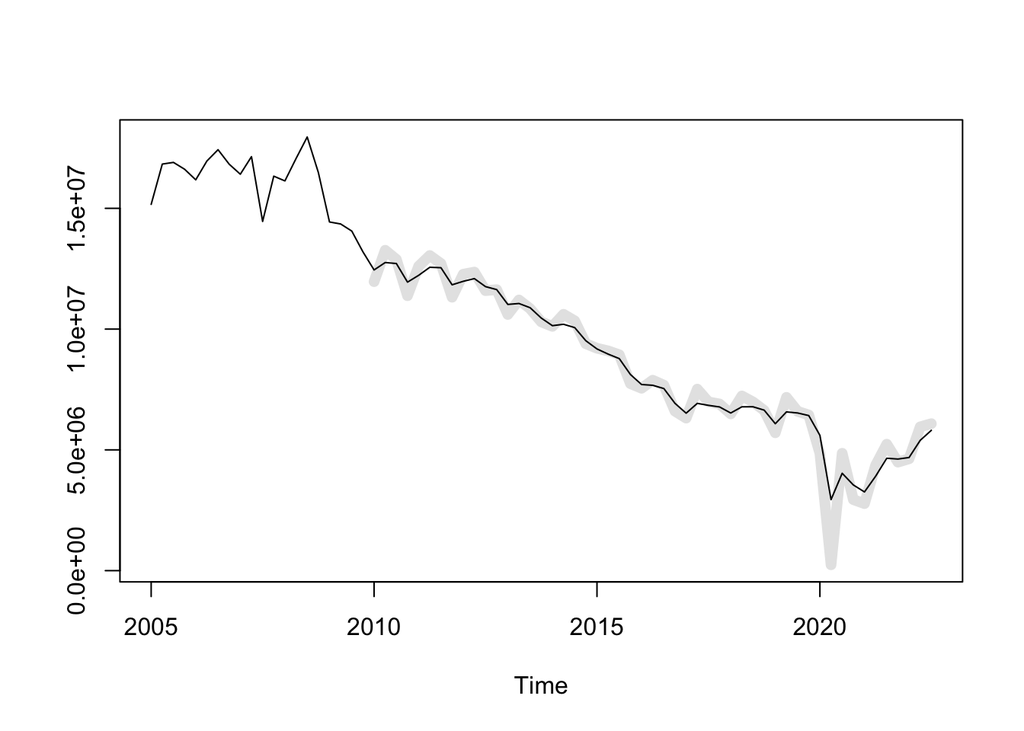

```r
arx = sarima(octa_q_ts2[,1], 0,0,0, xreg=octa_q_ts2[,2:3], details=FALSE)

pred <- octa_q_ts + resid(arx$fit) # 1-step-ahead predictions
ts.plot(pred, octa_q_ts, col=c('gray90',1), lwd=c(7,1))
```

Here we can see the errors are not autocorrelated, so we use the white noise model. The transfer function model appears to have worked pretty well here, and we can conclude that the lagged regression with a lag of 20 between Orange County bus ridership and California GDP is a good fit. This means that there is a lag of 5 years before changes in one variable affect the other.